# RIMA: RIgourous Matching of single-cell transcriptomics Atlases

Jacques Marc-Antoine

2025-11-14

# 1 Introduction

RIMA (RIgourous Matching of single-cell transcriptomics Atlases) is a package to match single-cell transcriptomics data across two datasets. It is particularly adapted for cases where integration is difficult (e.g. cross-species).

Unlike other methods, RIMA returns a mapping at the level cell neighbourhoods, and retains the quantitative gene expression of the neighbourhoods. This explicit matching can then be mined downstream for comparative insights between the two atlases.

RIMA’s pipeline is as follow:

1. Define neighbourhoods for each atlas independently (done using miloR’s functions).
2. Calculate neighbourhood-neighbourhood similarities across the atlases, for every pair of neighbourhoods.
3. Derive the significance of each neighbourhood pair by comparing their similarity to similarities obtained against scrambled neighbourhoods, where cell identities have been randomly resampled.
4. Using the significant neighbourhood pairs only, return a one-to-one neighbourhood matching which maximises the sum of the similarity of the matches.

Here we demonstrate RIMA’s usage on a small sample from the mouse and rabbit gastrulation atlases.

# 2 Load libraries and test dataset

```r
suppressPackageStartupMessages({
  library(RIMA)
  library(SingleCellExperiment)
  library(miloR)
  library(data.table)
  library(ggplot2)
  library(scater)
})
set.seed(7)

# SingleCellExperiment objects containing the gastrulation data
sce_mouse <- RIMA::sce_mouse_gastrulation
sce_rabbit <- RIMA::sce_rabbit_gastrulation

# Color scheme for cell types
l_ct_colors <- lapply(list(mouse = sce_mouse, rabbit = sce_rabbit), function(x) {
  as.data.table(unique(colData(x)[, c("celltype", "color")]))
})
dt_ct_palette <- unique(rbindlist(l_ct_colors))
```

# 3 Usage

## 3.1 Define neighbourhoods and preprocess for RIMA

Cell neighbourhoods are small groups of cells which bundles together very similar single cells. Working with cell neighbourhoods allows to retain near single-cell resolution, while mitigating sequencing noise. The neighbourhoods can be seen as capturing distinct cell states, which are more precise than cell types, and more robust to noise than single cells. We use the implementation in the miloR package to define the neighbourhoods.

```r
# PCA is a batch-corrected embedding, cells that are close to each other in this embedding will form neighbourhoods
define_neighbourhoods <- function(sce, prop_seeds, knn=10, reduced.dim="PCA"){
  n_components <- ncol(reducedDim(sce, reduced.dim))  # use all available PCs
  mi <- Milo(sce)
  mi <- miloR::buildGraph(mi, k = knn, d = n_components, reduced.dim = "PCA")
  mi <- miloR::makeNhoods(mi, prop = prop_seeds, k = knn, d=n_components, refined = TRUE)
  return(mi)
}

# prop_seeds controls the proportion of cells selected as neighbourhoods' seeds. Decrease to have less neighbourhoods.
mi_mouse <- define_neighbourhoods(sce_mouse, prop_seeds = 0.02)
mi_rabbit <- define_neighbourhoods(sce_rabbit, prop_seeds = 0.02)
```

In what follows, the atlases will be contained in Milo objects. Although Milo was developed for differential abundance testing, we do not make use of this functionality. Instead, we only use the Milo objects as extensions of SingleCellExperiment objects which can contain neighbourhoods. If you have already defined the neighbourhoods (possibly with another method), simply pass them to the @nhoods slot of the Milo objects. This needs to be a (sparse) matrix of shape [n_cell, n_nhoods], filled with 0s and 1s to indicate whether cells belong to the neighbourhoods.

```r
milos <- preprocess_milos(mi_mouse, mi_rabbit)
```

```
## Reading milo1...
## Reading milo2...
## Subset to/reorder genes of interest...
## Calculate nhoods expression...
```

```r
milos
```

```
## [[1]]
## class: Milo
## dim: 200 8607
## metadata(0):
## assays(1): logcounts
## rownames(200): ENSMUSG00000061808 ENSMUSG00000027562 ...
##   ENSMUSG00000013415 ENSMUSG00000027210
## rowData names(1): mgi_symbol
## colnames(8607): ext_cell_294006 ext_cell_157458 ... ext_cell_151967
##   ext_cell_151112
## colData names(3): celltype stage color
## reducedDimNames(1): PCA
## mainExpName: NULL
## altExpNames(0):
## nhoods dimensions(2): 8607 155
## nhoodCounts dimensions(2): 1 1
## nhoodDistances dimension(1): 0
## graph names(1): graph
## nhoodIndex names(1): 155
## nhoodExpression dimension(2): 200 155
## nhoodReducedDim names(0):
## nhoodGraph names(0):
## nhoodAdjacency dimension(2): 1 1
##
## [[2]]
## class: Milo
## dim: 200 7305
## metadata(0):
## assays(1): logcounts
## rownames(200): ENSMUSG00000061808 ENSMUSG00000027562 ...
##   ENSMUSG00000013415 ENSMUSG00000027210
## rowData names(2): mgi_symbol rabbit_one2one_ortholog
## colnames(7305): cell_167555 cell_94483 ... cell_49008 cell_106465
## colData names(3): celltype stage color
## reducedDimNames(1): PCA
## mainExpName: NULL
## altExpNames(0):
## nhoods dimensions(2): 7305 139
## nhoodCounts dimensions(2): 1 1
## nhoodDistances dimension(1): 0
## graph names(1): graph
## nhoodIndex names(1): 139
## nhoodExpression dimension(2): 200 139
## nhoodReducedDim names(0):
## nhoodGraph names(0):
## nhoodAdjacency dimension(2): 1 1
```

## 3.2 Calculate neighbourhood-neighbourhood similarities across the atlases

```r
dt_sims <- RIMA::calculate_similarities(milos, method = "spearman")
head(dt_sims)
```

| nhoods1 | nhoods2 | sim |
| --- | --- | --- |
| 1335 | 868 | 0.6465925 |
| 4559 | 868 | 0.7092634 |
| 3410 | 868 | 0.5954287 |
| 5936 | 868 | 0.6298908 |
| 1439 | 868 | 0.6912843 |
| 6332 | 868 | 0.7058063 |

## 3.3 Derive the significance of each neighbourhood-neighbourhood pair

```r
dt_sims_withSignif <- RIMA::calculate_nhoodnhood_significance(
  milos,
  dt_sims,
  n_scrambles = 10,
  col_scramble_label = "celltype",
  alpha = 0.05,
  direction = "b"
)
```

```r
head(dt_sims_withSignif)
```

| nhoods1 | nhoods2 | sim | sim_lr | pval_lr | pval_adjusted_lr | sim_rl | pval_rl | pval_adjusted_rl | pval_combined | pval_adjusted_combined | is_significant |
| --- | --- | --- | --- | --- | --- | --- | --- | --- | --- | --- | --- |
| 1036 | 1007 | 0.5957121 | 0.5957121 | 0.0028777 | 0.3453237 | 0.5957121 | 1 | 1 | 0.0057554 | 1 | FALSE |
| 1036 | 1028 | 0.5597658 | 0.5597658 | 0.2172662 | 1.0000000 | 0.5597658 | 1 | 1 | 0.4345324 | 1 | FALSE |
| 1036 | 1049 | 0.5833816 | 0.5833816 | 0.0287770 | 1.0000000 | 0.5833816 | 1 | 1 | 0.0575540 | 1 | FALSE |
| 1036 | 1064 | 0.5797354 | 0.5797354 | 0.0438849 | 1.0000000 | 0.5797354 | 1 | 1 | 0.0877698 | 1 | FALSE |
| 1036 | 1162 | 0.5865226 | 0.5865226 | 0.0194245 | 1.0000000 | 0.5865226 | 1 | 1 | 0.0388489 | 1 | FALSE |
| 1036 | 1163 | 0.6005298 | 0.6005298 | 0.0007194 | 0.0913669 | 0.6005298 | 1 | 1 | 0.0014388 | 1 | FALSE |

### 3.3.1 Inspect the effect of trimming insignificant nhood-nhood edges

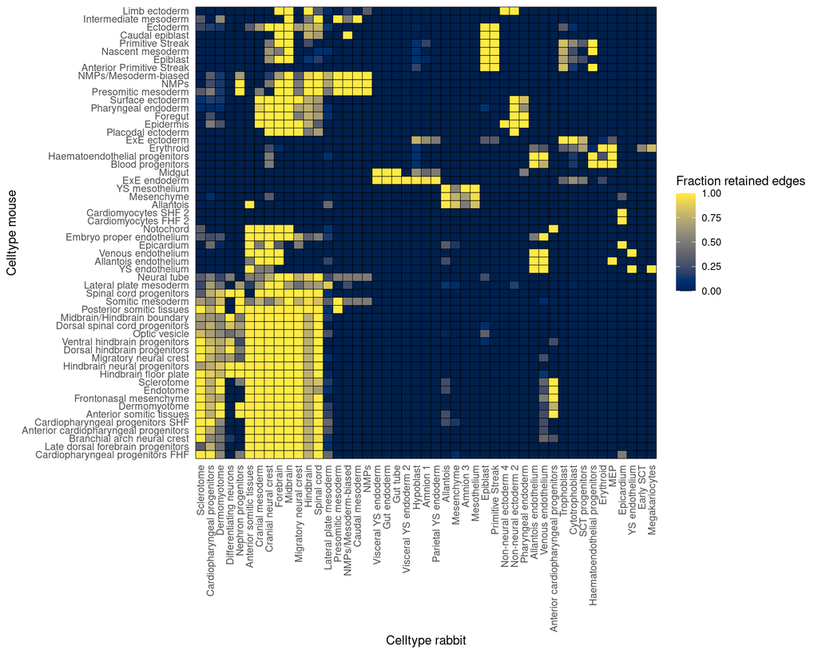

```r
RIMA::plot_trimming_map(milos, dt_sims_withSignif, cols_label = c("celltype", "celltype")) + labs(x="Celltype rabbit", y="Celltype mouse")
```

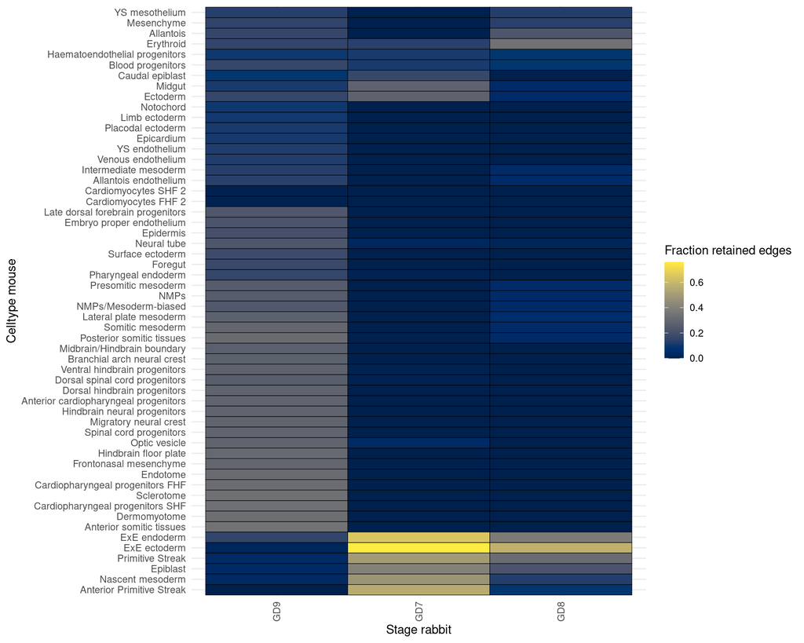

```r
RIMA::plot_trimming_map(milos, dt_sims_withSignif, cols_label = c("celltype", "stage")) + labs(x="Stage rabbit", y="Celltype mouse")
```

## 3.4 Match the significant neighbourhood-neighbourhood pairs

```r
dt_match <- RIMA::match_nhoods(dt_sims_withSignif[is_significant == TRUE])
head(dt_match)
```

| nhoods1 | nhoods2 | sim |
| --- | --- | --- |
| 1036 | 2115 | 0.6430504 |
| 1263 | 1728 | 0.7316396 |
| 1299 | 1795 | 0.7291078 |
| 1358 | 1764 | 0.7087169 |
| 1559 | 3220 | 0.7609723 |
| 1586 | 3288 | 0.7541665 |

# 4 Inspect matching results

## 4.1 Side-by-side embeddings with matches

```r
# UMAP 2D embedding for visualisation
milos <- lapply(milos, function(x) {
  scater::runUMAP(x, ncomponents = 2, dimred = "PCA")
})
```

```r
p <- RIMA::plot_matches_embed(milos, dt_match, dt_palette = dt_ct_palette, cols_color = c("celltype", "celltype")) + guides(fill="none")
```

```
## Converting celltype to factor...
## Converting celltype to factor...
```

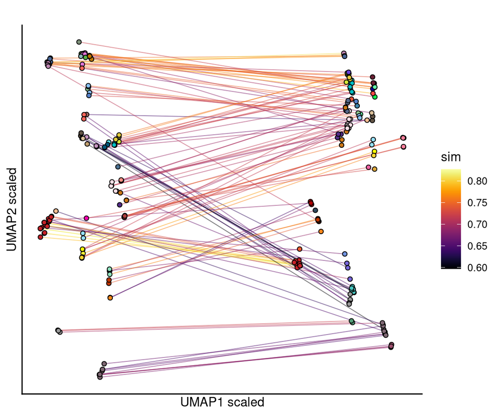

```r
p
```

## 4.2 Annotations of matched neighbourhoods

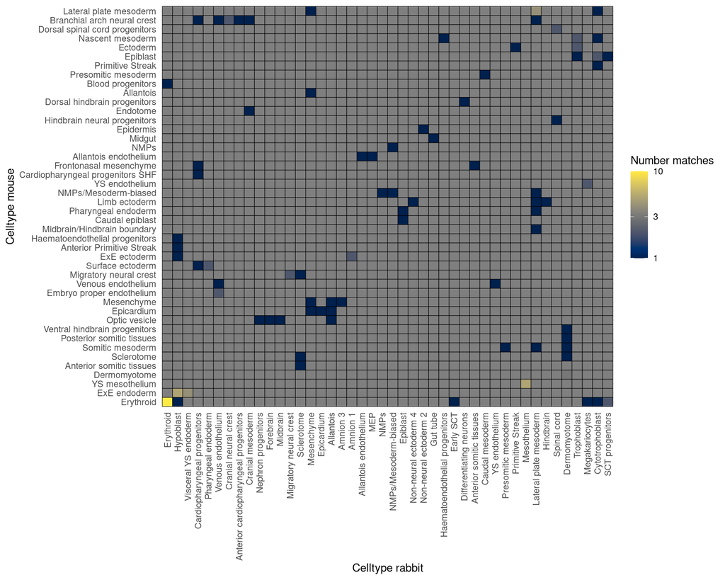

```r
RIMA::plot_matches_map(milos, dt_match, cols_label = c("celltype", "celltype"), transform="log10")  + labs(x="Celltype rabbit", y="Celltype mouse")
```

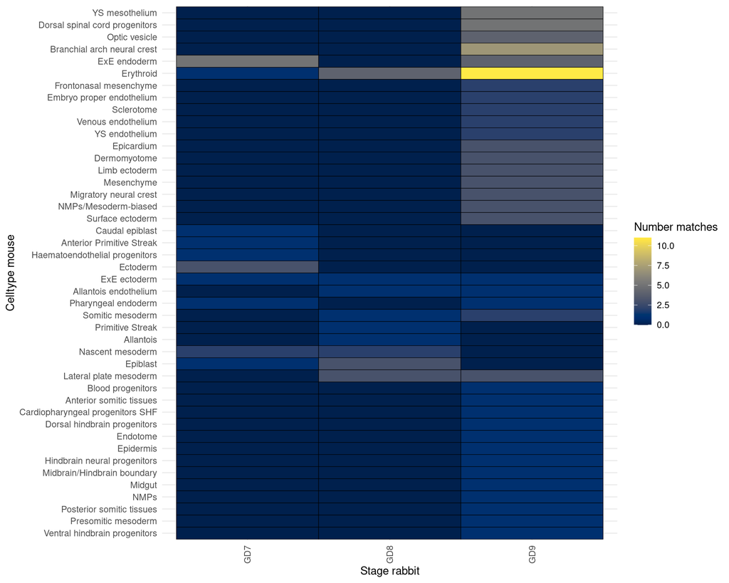

```r
RIMA::plot_matches_map(milos, dt_match, cols_label = c("celltype", "stage"), cluster_cols = FALSE)  + labs(x="Stage rabbit", y="Celltype mouse")
```

# 5 Identify conserved gene expression with CoPE score

```r
# Set genes to NULL to calculate CoPE of all the genes
dt_copes <- RIMA::calculate_cope(milos, dt_match, genes = NULL)

# Most and least conserved gene expression across matched neighbourhoods
setorder(dt_copes, cope)
top_genes <- tail(dt_copes[!is.na(cope), gene], 3)
worst_genes <- head(dt_copes[!is.na(cope), gene], 3)

dt_copes[gene %in% c(top_genes, worst_genes)]
```

| gene | cope |
| --- | --- |
| ENSMUSG00000029064 | -0.3015752 |
| ENSMUSG00000071547 | -0.2348185 |
| ENSMUSG00000021728 | -0.2292171 |
| ENSMUSG00000020733 | 0.7019771 |
| ENSMUSG00000004885 | 0.7083475 |
| ENSMUSG00000040466 | 0.7188674 |

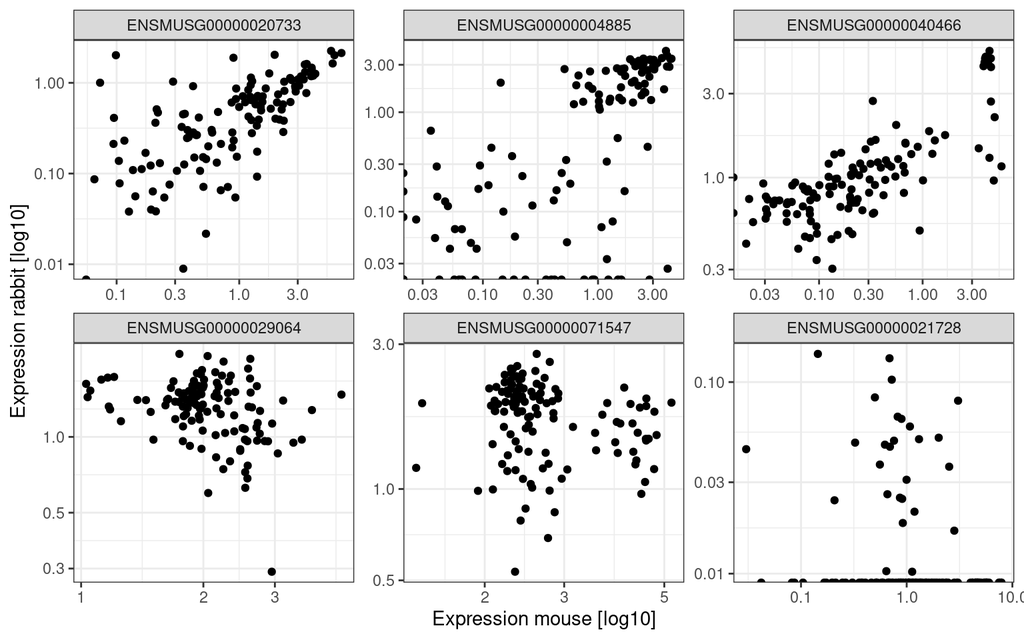

```r
RIMA::plot_paired_expression(milos, dt_match, c(top_genes, worst_genes)) + scale_x_log10() + scale_y_log10() + labs(x="Expression mouse [log10]", y="Expression rabbit [log10]")
```